# ARMA investigation

Taken from arma_scenario_gen.R

Plot of error as a fraction of total demand

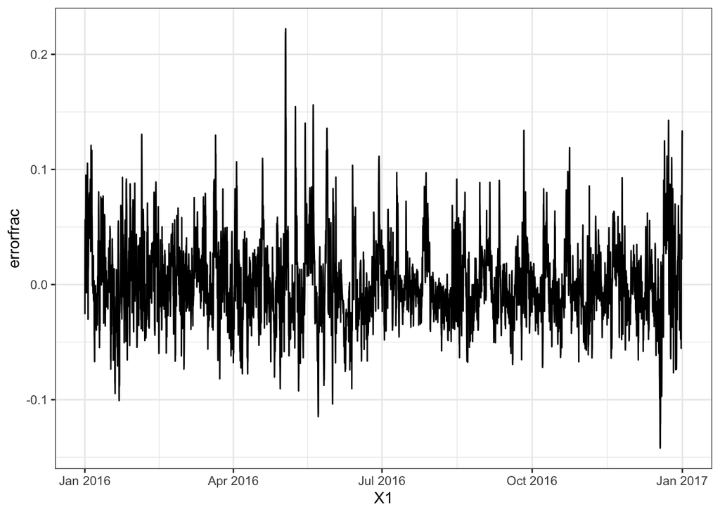

```r
ggplot(dercot[errsel16,], aes(x=X1, y = errorfrac)) + geom_line() +theme_bw()
```

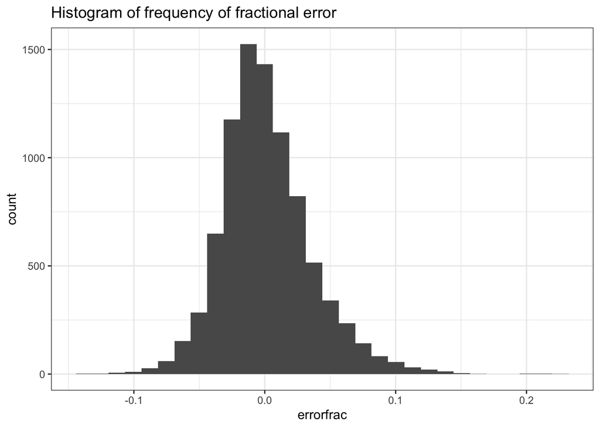

```r
ggplot(dercot[errsel16,],aes(x=errorfrac)) + geom_histogram() + theme_bw() +
  labs(title = "Histogram of frequency of fractional error")
```

acf and pacf plots of fractional error

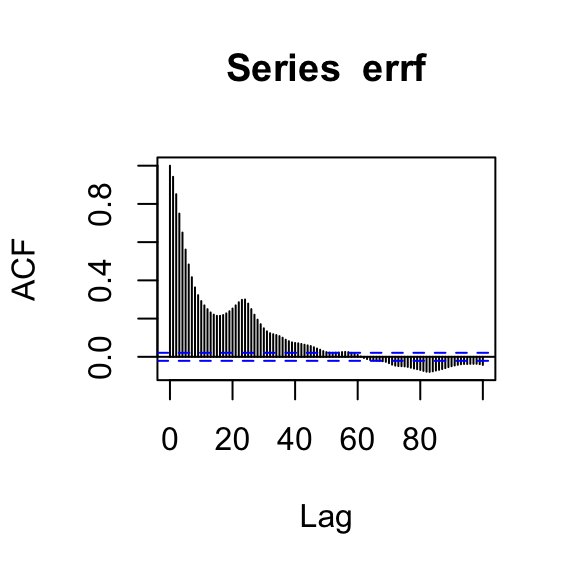

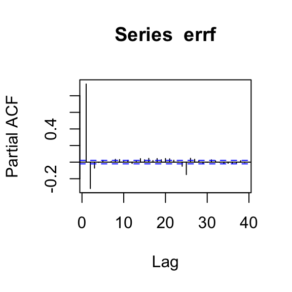

The ACF declines gradually while the PACF declines much more rapidly, which indicates an AR model. But what order of AR model? AR(3). Or AR(25) ish… a lag of 24 is significant for obvious reasons, and there are a few significant intervals after that.

# Implementing an AR(>= 24) model

We should test an AR model with p=3,24,25,26. We can validate the goodness of simulation by how closely the summary statistics match the original dataset.

```
## [1] "Original data summary stats"
```

```
##      Min.   1st Qu.    Median      Mean   3rd Qu.      Max.
## -0.142018 -0.020429 -0.002668  0.001531  0.020008  0.222191
```

```
## [1] "AR(3) model results:"
## [1] "Simulation summary stats"
##      Min.   1st Qu.    Median      Mean   3rd Qu.      Max.
## -0.336742 -0.070668  0.001298  0.005440  0.079212  0.343753
## [1] "Difference between original and simulation"
##      Min.   1st Qu.    Median      Mean   3rd Qu.      Max.
##  0.194724  0.050239 -0.003966 -0.003909 -0.059205 -0.121562
## [1] "Add a correction in which simulation is divided by the ratio of the two SDs"
##       Min.    1st Qu.     Median       Mean    3rd Qu.       Max.
## -0.0346084  0.0021119 -0.0030820 -0.0002044 -0.0052583  0.1125455
##
##
## [1] "AR(24) model results:"
## [1] "Simulation summary stats"
##      Min.   1st Qu.    Median      Mean   3rd Qu.      Max.
## -0.297675 -0.072860 -0.003382  0.001946  0.069509  0.381010
## [1] "Difference between original and simulation"
##       Min.    1st Qu.     Median       Mean    3rd Qu.       Max.
##  0.1556573  0.0524314  0.0007136 -0.0004152 -0.0495012 -0.1588185
## [1] "Add a correction in which simulation is divided by the ratio of the two SDs"
##       Min.    1st Qu.     Median       Mean    3rd Qu.       Max.
## -0.0436001  0.0036603 -0.0015500  0.0008875 -0.0029734  0.0962215
##
##
## [1] "AR(25) model results:"
## [1] "Simulation summary stats"
##     Min.  1st Qu.   Median     Mean  3rd Qu.     Max.
## -0.29581 -0.03922  0.03035  0.03088  0.10354  0.47311
## [1] "Difference between original and simulation"
##     Min.  1st Qu.   Median     Mean  3rd Qu.     Max.
##  0.15379  0.01879 -0.03302 -0.02935 -0.08354 -0.25092
## [1] "Add a correction in which simulation is divided by the ratio of the two SDs"
##      Min.   1st Qu.    Median      Mean   3rd Qu.      Max.
## -0.050158 -0.008249 -0.012093 -0.008057 -0.012147  0.075273
##
##
## [1] "AR(26) model results:"
## [1] "Simulation summary stats"
##      Min.   1st Qu.    Median      Mean   3rd Qu.      Max.
## -0.312733 -0.097402 -0.001419 -0.003361  0.091684  0.355223
## [1] "Difference between original and simulation"
##      Min.   1st Qu.    Median      Mean   3rd Qu.      Max.
##  0.170716  0.076973 -0.001249  0.004892 -0.071676 -0.133032
## [1] "Add a correction in which simulation is divided by the ratio of the two SDs"
##      Min.   1st Qu.    Median      Mean   3rd Qu.      Max.
## -0.050561  0.008055 -0.002253  0.002514 -0.006804  0.118309
```

Go back to arma_scenario_gen.R to create and save simulations based on that. Use a correction.

# ACF and PACF of diff(errf)

Just to test, we can look at the PACF and ACF when we take one diff

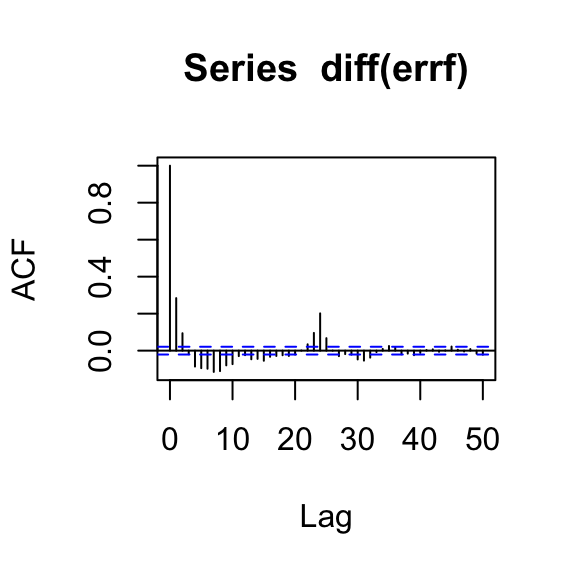

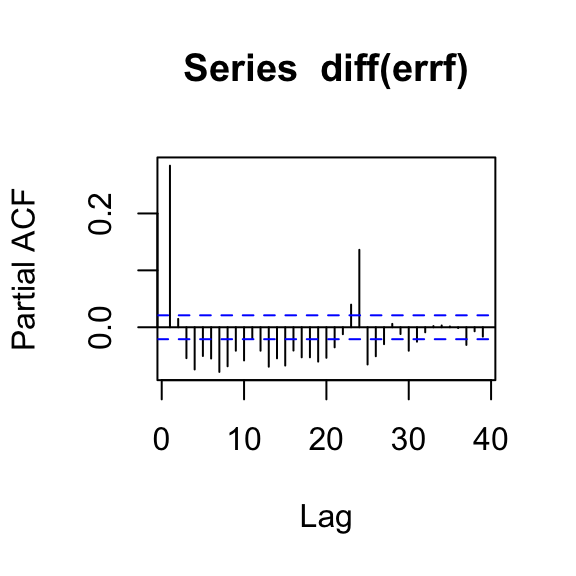

```r
acf(diff(errf), lag.max = 50)
pacf(diff(errf))
```

This doesn’t appear to be an improvement, so lets stick with our AR() model found above.